# Primeros pasos con R (y RStudio)

Módulo práctico de ITA  
(Grupo M)

## Antes de abrir … un consejo

En serio, completamente en serio!!

### 1. Es muy-muy importante la actitud!!!

##### Hay que intentar no agobiarse …

[figure not shown]

**Errores tontos**, [tendremos unos cuantos](https://twitter.com/cogscimom/status/1354508785365078016/photo/1). Puede que os resulte un poco frustrante, pero es [completamente normal](https://twitter.com/allison_horst/status/1213275783675822080)!! Hay que pasar por ello!! 🙆‍♀️

#### … mejor dejarse llevar

[figure not shown]

### Vengaaaa, vamos allá!!!!

[figure not shown]

## Un poco de contexto/historía (sobre R)!!!

##### ¿qué es R?

- Es un **entorno** para hacer **análisis estadísticos**; de hecho, la página oficial de R se llama [The R Project for Statistical Computing](https://www.r-project.org/)
- También es un **lenguaje de programación**
- R se distribuye bajo la licencia GNU GPL; o sea, es **software libre**

##### ¿cuando fue creado?

- En 1993, por **R. Ihaka** y **R. Gentleman** de la Universidad de Auckland
- … pero actualmente, el entorno R es el resultado de la colaboración de la **comunidad de usuarios de R** … que amplian las funcionalidades de R con **paquetes**.

##### ¿qué es RStudio?

- Intuitivamente es un **programa que facilita dar nuestras ordenes a R**.
- Técnicamente es un **IDE** (Integrated development environment) diseñado especialmente para R

#### Es importante entender la diferencia entre R y RStudio

- **R**, : es un entorno/programa para hacer análisis estadísticos y también es un lenguaje de programación
- **RStudio**, : es un programa que sirve para poder usar R de manera más cómoda y eficiente.

#### Nosotros no veremos a R, sino que daremos ordenes a R a traves de RStudio

# Historia reciente de R

R-base vs. tidyverse

- R **era** un lenguaje “oscuro” para estadísticos y académicos, pero …
- … recientemente ha habido una especie de **revolución** en el universo
- [Hadley Wickham](http://hadley.nz/), científico jefe de RStudio, [revolucionó el universo](https://priceonomics.com/hadley-wickham-the-man-who-revolutionized-r/?utm_campaign=Data%2BElixir&utm_medium=email&utm_source=Data_Elixir_46) , creando el ‘*Hadleyverse*’

[figure not shown]

- El ‘*Hadleyverse*’, se ha convertido en el [tidyverse](https://www.tidyverse.org/) gracias a un grupo de desarrolladores; por ejemplo:

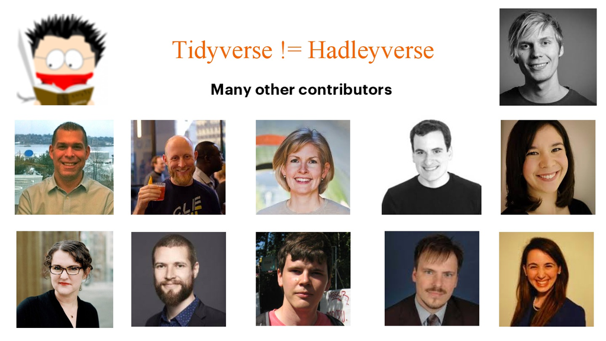

### R-base vs. tidyverse

- Podemos pensar que hay 2 formas de escribir código en : R-base y tidyverse.
- Nosotros escribiremos, principalmente, **à la tidyverse**.
- Escribir *à la tidyverse* [tiene ventajas](https://x.com/andrewheiss/status/1359583543509348356) y, además, es que [ya es el estándar](https://twitter.com/R_Hisp/status/1399635575712399360)

### Recuerda que es muy importante la actitud!!!

##### Hay que intentar no agobiarse …

[figure not shown]

#### … mejor dejarse llevar

[figure not shown]

Es lo primero que hemos de aprender

### **Siempre** daremos las ordenes a R a través de RStudio

- Si abres RStudio verás algo parecido a esto

[figure not shown]

- Como ves, la interfaz de RStudio tiene (al principio) 3 paneles
- La Consola es el panel de la izquierda
- Empezaremos dando ordenes a R escribiendo en la **Consola**

1. En la **consola**: solo hay que escribir la orden y pulsar la tecla **ENTER**

**Tarea 1.1: Dando ordenes a R a través de la CONSOLA**

**Tarea 1.2: Dando ordenes a R usando un script**

- Intenta darle a R la orden de sumar `2+2`, pero esta vez usando un script o fichero `.R`

**Tarea 1.3: Guardando el script**

- Guarda el fichero que has creado. Ponle el nombre “prueba_01.R”. ¿Donde se ha guardado?

### Seguimos dando ordenes a R

**Tarea 1.3: Dando varias ordenes a R**

1. Cierra RStudio
2. Ejecuta las siguientes lineas de código en R

```r
# operaciones básicas con R
2 + 2
2 - 2
2 * 2
2 / 2

# Potenciación (se puede hacer con el operador ^ o con **)
3^2
3**2

# raíz cuadrada
sqrt(9)
```

- ¿Cómo lo has hecho? ¿Qué ha ocurrido?
- ¿Las has ejecutado todas de golpe o una a una?
- ¿Alguien se ha atascado? No … a ver quien puede hacer que R se atasque.

## Creación (y gestión) de Rprojects

Siempre trabajaremos dentro de un **proyecto**, así que hay que saber crearlos y gestionarlos

### Durante el curso siempre trabajaremos con Rprojects

Para **crear un Rproject** has de:

1. Abrir RStudio
2. Seguir la siguiente ruta de menús: File > New Project > New Directory > New Project
3. Guardar el RProject; para ello has de ponerle un nombre y decidir la ruta donde se creará el RProject

**Tarea 1.4: creación de proyectos**

Crea un Rproject en el escritorio/Desktop de tu ordenador. Ponle el nombre: “my_proyecto_01”

**Tarea 1.4b: creación de proyectos**

1. Cierra RStudio
2. Borra el Rproject “my_proyecto_01”
3. Crea un nuevo Rproject llamado “my_proyecto_02”
4. Cierra RStudio

### Aprender a abrir correctamente un RProject es muy importante!!

Hay 2 formas de abrirlo:

1. Abrir la carpeta del RProject y hacer doble-click en el archivo con extensión `.Rproj` (sí el fichero con el icono de un cubo azulito)
2. La segunda forma es abrir RStudio y pinchar en el desplegable que hay en la esquina superior-derecha.

Si abres los Rprojects correctamente, **RStudio reconocerá la carpeta como un Rproject**, facilitándonos algunas cosas que veremos más adelante

**Tarea 1.5: abriendo correctamente un Rproject**

- Cierra RStudio ( si es que aun lo tienes abierto)
- Abre el proyecto “my_proyecto_02”

### Gestión de archivos y carpetas **dentro de un Rproject**

- Los **Rprojects** son carpetas normales y corrientes para tu sistema operativo; por lo tanto, puedes manejarlas desde tu sistema operativo de la forma habitual
- OK, **PERO**, generalmente manejaremos los Rprojects desde RStudio, así que es importante saber crear/borrar/renombrar y organizar archivos desde RStudio
- Vamos a practicarlo un poco

### Organizando nuestro Rproject

Los Rprojects son carpetas donde guardaremos todos los ficheros que nos hagan falta para un análisis de datos. Generalmente nos harán falta datos, imágenes, … Es mejor ser organizado y guardar los datos en una carpeta, las imágenes en otra, etc …

##### En un Rproject podemos crear carpetas de 2 maneras:

1. Desde tu sistema operativo. Seguro que has creado carpetas!!!
2. Desde RStudio. En el panel inferior-derecha. En la pestaña “Files”, verás un icono que pone “New Folder”. Pínchalo y …

**Tarea 1.6: creando (y borrando) carpetas en nuestro Rproject**

- Crea dos subcarpetas dentro de tu Rproject. Una que se llame “datos” y otra que se llame “imagenes”
- Borra la carpeta “imagenes” que has creado

**Tarea 1.6b: creando (y borrando) script’s en nuestro Rproject**

- Dentro del Rproject en el que estamos trabajando (`my_proyecto_02`), crea un script (o fichero `.R`) llamado `script_01.R`
- Crea un segundo script llamado `script_02.R`
- Cambia el nombre de `script_02.R` . Concretamente llamalo `script_44.R`
- Borra el script `script_44.R`

### Dar órdenes a R (otra vez)

- Sí, esto fue lo primero que hicimos, pero ahora vamos a dar ordenes a R desde dentro del Rproject (realmente es igual, pero … estamos empezando)

**Tarea 1.7: dando ordenes a R desde un Rproject**

1. Cierra RStudio
2. Vuelve a abrir el Rproject “my_proyecto_02”
3. Desde el RProject, ejecuta las siguientes lineas de código en R
4. No las ejecutes desde la consola, sino desde un archivo .R. Guarda el archivo y llámalo “mis_calculos_01.R”

```r
#- Ante la duda usa los paréntesis
6 + 2 * 5
(6 + 2) * 5

#- Operaciones de varias lineas
2 + 2 + 2 + 2 + 2 +
10 +
30
```

- ¿Donde has guardado el archivo “mis_calculos_01.R”?

Hay que aprender a borrar, crear y mover archivos dentro del Rproject (es fácil)

**Tarea 1.7: gestionando tu Rproject**

- Crea otro archivo llamado “mis_calculos_02.R” en la carpeta “datos”. En este archivo tienes que escribir una linea de comentario y una linea con una expresión/orden de R.
- Mueve el archivo “mis_calculos_02.R” de la carpeta “datos” a la carpeta raíz del Rproject.
- Bueno, pues yo creo que suficiente: ya sabemos manejarnos con RStudio.
- ¿Recordáis que es RStudio? ¿Qué es un Rproject?
- ¿Y la consola? ¿Y los ficheros .R?

## Vamos a hacer memes

Nos servirá para seguir familiarizándonos con RStudio y empezar a usar funciones en R

Usaremos el [guion_01](https://perezp44.github.io/ITA-26-27-web/guiones/guion_01_ITA)

[figure not shown]

[figure not shown]

[figure not shown]

[figure not shown]

[figure not shown]

[figure not shown]

[figure not shown]

[figure not shown]

[figure not shown]